# Loan Data from Prosper

## Dataset Overview

[Dataset Download](https://s3.amazonaws.com/udacity-hosted-downloads/ud651/prosperLoanData.csv)  
[Dataset Description](https://docs.google.com/spreadsheets/d/1gDyi_L4UvIrLTEC6Wri5nbaMmkGmLQBk-Yx3z0XDEtI/edit#gid=0)

This data set contains `113,937 rows` and `81 columns`. each row has information on the borrow's APR, status, borrowed amount, debt, etc. Variables with many missing values will be dropped to make the Dataset more accurate. Outliers were also will be removed to provide more reliable Data.

```python
import numpy as np
import pandas as pd
import matplotlib.pyplot as plt
import seaborn as sns

%matplotlib inline

import warnings
warnings.simplefilter("ignore")
```

```python
loan = pd.read_csv('prosperLoanData.csv')
```

```python
cols = ['LoanOriginalAmount', 'BorrowerAPR', 'StatedMonthlyIncome',
        'Term', 'ProsperRating (Alpha)', 'EmploymentStatus' , 'ListingCategory (numeric)',
       'ProsperScore']
loan_sub = loan[cols]
```

```python
# data wrangling, remove loans with missing borrower APR information
loan_sub = loan_sub[~loan_sub.BorrowerAPR.isna()]
# data wrangling, remove loans with stated monthly income greater than 30k, which are outliers
loan_sub = loan_sub[loan_sub.StatedMonthlyIncome <= 30000]
```

```python
# Convert ProsperRating and Employment status into ordered categorical types
rate_order = ['HR','E','D','C','B','A','AA']
ordered_var = pd.api.types.CategoricalDtype(ordered = True,
                                    categories = rate_order)
loan_sub['ProsperRating (Alpha)'] = loan_sub['ProsperRating (Alpha)'].astype(ordered_var)

emp_order = ['Employed','Self-employed','Full-time','Part-time','Retired','Other','Not employed', 'Not available']
ordered_var = pd.api.types.CategoricalDtype(ordered = True,
                                    categories = emp_order)
loan_sub['EmploymentStatus'] = loan_sub['EmploymentStatus'].astype(ordered_var)
loan_sub.shape
```

```
(113585, 8)
```

## Distribution of BorrowerAPR

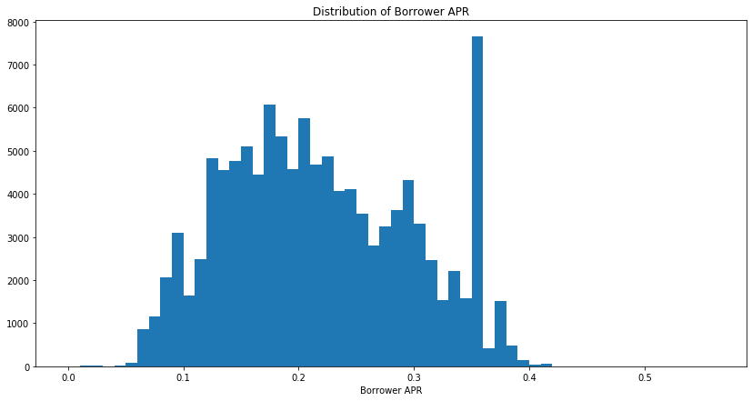

```python
bins = np.arange(0, loan_sub.BorrowerAPR.max() + 0.05, 0.01)
plt.figure(figsize = [14, 7])
plt.hist(data = loan_sub, x = 'BorrowerAPR', bins = bins);
plt.xlabel('Borrower APR');
plt.title('Distribution of Borrower APR');
```

## Counts of listing labels in our data

```python
list_cat={0:'Not Available',1:'Debt Consolidation',2:'Home Improvement',
          3:'Business',4:'Personal Loan',5:'Student Use',6:'Auto',
          7:'Other',8:'Baby&Adoption',9:'Boat',10:'Cosmetic Procedure',
          11:'Engagement Ring',12:'Green Loans',13:'Household Expenses',
          14:'Large Purchases',15:'Medical/Dental',16:'Motorcycle',
          17:'RV',18:'Taxes',19:'Vacation',20:'Wedding Loans'}
```

```python
l=[]
for i in range(loan_sub.shape[0]):
    for j in range(len(list_cat)):
        if loan_sub['ListingCategory (numeric)'].values[i] == list(list_cat.keys())[j]:
            l.append(list(list_cat.values())[j])
```

**Assigning a new column with listing labels.**

```python
loan_sub['ListingLabels'] = l
```

```python
loan_sub.head(5)
```

|  | LoanOriginalAmount | BorrowerAPR | StatedMonthlyIncome | Term | ProsperRating (Alpha) | EmploymentStatus | ListingCategory (numeric) | ProsperScore | ListingLabels |
| --- | --- | --- | --- | --- | --- | --- | --- | --- | --- |
| 0 | 9425 | 0.16516 | 3083.333333 | 36 | NaN | Self-employed | 0 | NaN | Not Available |
| 1 | 10000 | 0.12016 | 6125.000000 | 36 | A | Employed | 2 | 7.0 | Home Improvement |
| 2 | 3001 | 0.28269 | 2083.333333 | 36 | NaN | Not available | 0 | NaN | Not Available |
| 3 | 10000 | 0.12528 | 2875.000000 | 36 | A | Employed | 16 | 9.0 | Motorcycle |
| 4 | 15000 | 0.24614 | 9583.333333 | 36 | D | Employed | 2 | 4.0 | Home Improvement |

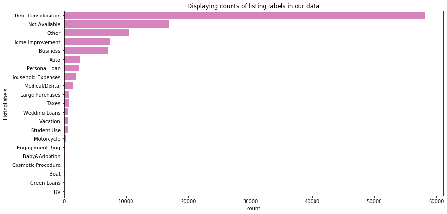

```python
plt.figure(figsize = (14,7))
sns.countplot(y = 'ListingLabels',data = loan_sub,
              order = loan_sub['ListingLabels'].value_counts().index,color = sns.color_palette()[6])
plt.title('Displaying counts of listing labels in our data');
```

This means that the **maximum** number of loans is taken for the **debt consolidation** category.  
This may mean that **many borrowers already have existing debts** which is why they take debt consolidation loans in order **to reduce the burden of existing debts and offer a new loan every month at low interest.**

## Borrower APR vs. Loan Amount

We can see that there is a gradual decrease in Borrower APR with loan amount still it dosn't give a clear picture of count of APR between a given range of loan amount.

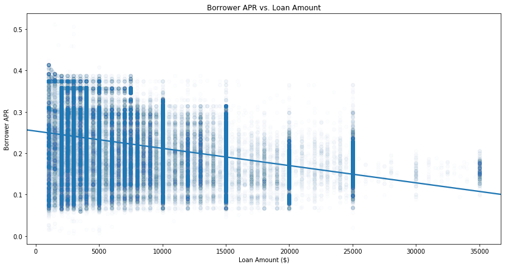

```python
plt.figure(figsize = [14, 7])
sb.regplot(data = loan_sub, x = 'LoanOriginalAmount', y = 'BorrowerAPR', scatter_kws={'alpha':0.01});
plt.xlabel('Loan Amount ($)')
plt.ylabel('Borrower APR')
plt.title('Borrower APR vs. Loan Amount');
```

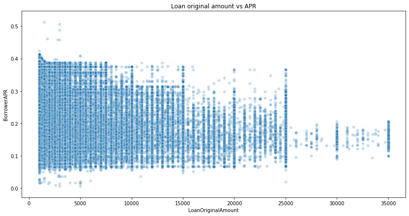

```python
plt.figure(figsize = (14,7))
sns.scatterplot(x = 'LoanOriginalAmount', y = 'BorrowerAPR',
                data = loan_sub, x_jitter = 0.3, alpha =1/4)
plt.title('Loan original amount vs APR')
```

## BorrowerAPR vs ProsperScore on each ProsperRatings

This visualization helps to analyze BorrowerAPR vs ProsperScore on different letter ratings. The patterns shows the lowerest rating(HR) of borrowers have the highest APR percentage, and borrowers with high rating (AA) has the lowers APR percentage. This visualization differentiate groups of people in terms of APR received.

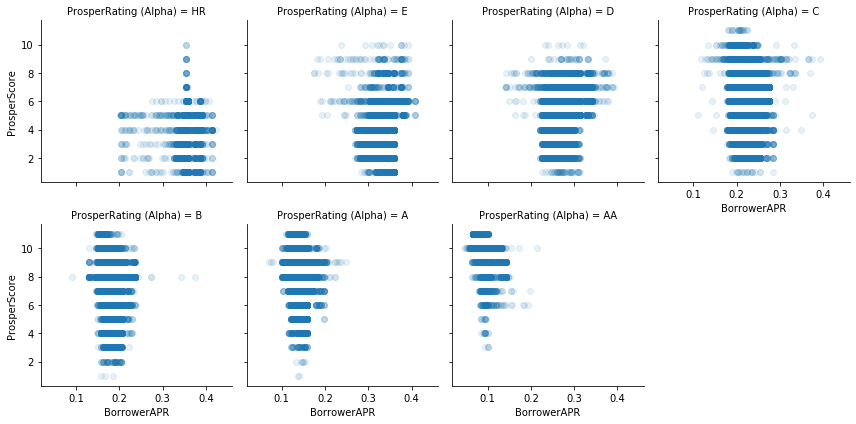

```python
g = sb.FacetGrid(data = loan_sub, col = 'ProsperRating (Alpha)', col_wrap = 4, size = 3)
g.map(plt.scatter, 'BorrowerAPR', 'ProsperScore', alpha = 0.1)
g.set_xlabels('BorrowerAPR')
g.set_ylabels('ProsperScore')

plt.show()
```

## BorrowerAPR vs. ProsperScore

A PerosperScore was given to each borrowers. The higher the score, the better rating the borrower were received. The plot shows the negative correlation between BorrowerAPR and ProsperScore. The plot explain the higher the APR, the lower the ProsperScore is. This makes sense because borrowers with higher rating tend to received lower interest rate and APR.

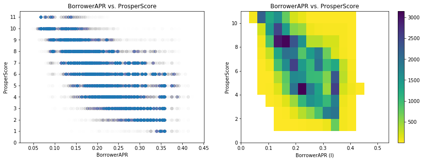

```python
# scatter and heat plot for comparing ProsperScore and BorrowerAPR.
plt.figure(figsize = [15, 5])

plt.subplot(1, 2, 1)
plt.scatter(data = loan_sub, x = 'BorrowerAPR', y = 'ProsperScore', alpha =  0.005)
plt.yticks(np.arange(0, 12, 1))
plt.title('BorrowerAPR vs. ProsperScore')
plt.xlabel('BorrowerAPR')
plt.ylabel('ProsperScore')


plt.subplot(1, 2, 2)
bins_x = np.arange(0, loan_sub['BorrowerAPR'].max()+0.05, 0.03)
bins_y = np.arange(0, loan_sub['ProsperScore'].max()+1, 1)
plt.hist2d(data = loan_sub, x = 'BorrowerAPR', y = 'ProsperScore', bins = [bins_x, bins_y],
               cmap = 'viridis_r', cmin = 0.5)
plt.colorbar()
plt.title('BorrowerAPR vs. ProsperScore')
plt.xlabel('BorrowerAPR (l)')
plt.ylabel('ProsperScore');
```

## Borrower APR by Rating and Term

Interestingly, the borrower APR decrease with the increase of borrow term for people with HR-C raings. But for people with B-AA ratings, the APR increase with the increase of borrow term.

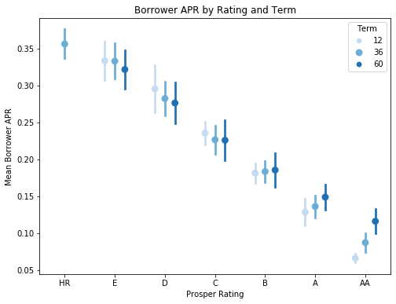

```python
fig = plt.figure(figsize = [8,6])
ax = sb.pointplot(data = loan_sub, x = 'ProsperRating (Alpha)', y = 'BorrowerAPR', hue = 'Term',
           palette = 'Blues', linestyles = '', dodge = 0.4, ci='sd')
plt.title('Borrower APR across rating and term')
plt.ylabel('Mean Borrower APR')
plt.xlabel('Prosper Rating')
plt.title('Borrower APR by Rating and Term')
```

## Prosper Rating Effect on Relationship between APR and Loan Amount

The loan amount increases with better rating. The borrower APR decreases with better rating. Interestingly, the relationship between borrower APR and loan amount turns from negative to slightly positive when the Prosper ratings are increased from HR to A or better. This is may because people with A or AA ratings tend to borrow more money, increasting APR could prevent them borrow even more and maximize the profit. But people with lower ratings tend to borrow less money, decreasing APR could encourage them to borrow more.

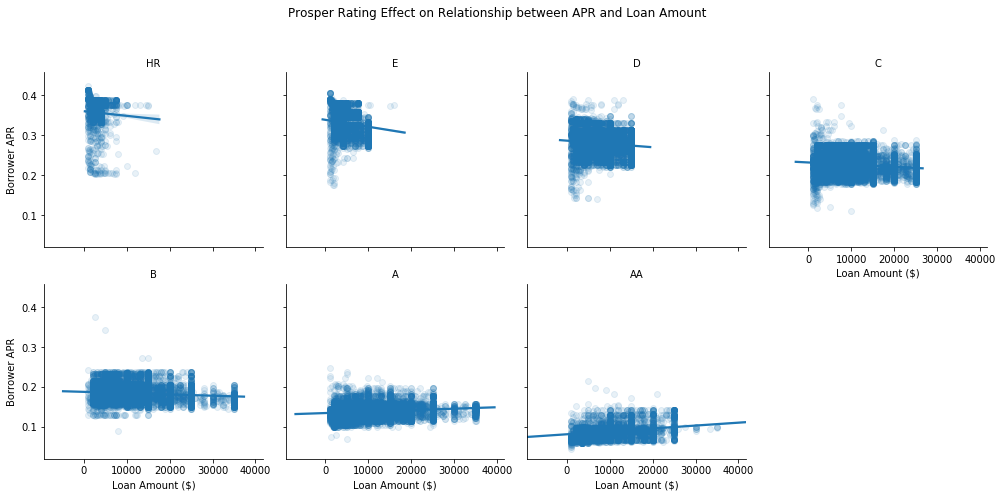

```python
g = sb.FacetGrid(data = loan_sub, col = 'ProsperRating (Alpha)', height = 3.5, col_wrap = 4)
g.map(sb.regplot, 'LoanOriginalAmount', 'BorrowerAPR', x_jitter=0.04, scatter_kws={'alpha':0.1});
g.set_titles('{col_name}')
g.add_legend()
g.set_xlabels('Loan Amount ($)')
g.set_ylabels('Borrower APR')
plt.suptitle('Prosper Rating Effect on Relationship between APR and Loan Amount');
plt.subplots_adjust(top = 0.85)
```